# Assignment 2

Beth Boos, Katie Loesser, & Zack Loken

2/17/2022

### Background

The group was interested in evaluating how water bodies and vegetation coverage influence bird abundance in coastal Louisiana. Specifically, we chose to look at Terrebonne Basin, an abandoned delta complex, in southeast Louisiana. This area has a diverse landscape and habitats including agriculture fields, wetlands, bayous, lakes, fresh and saltwater marshes, and urban areas. To evaluate this question, we chose three databases to link: [eBird](https://ebird.org/home), [Coastwide Reference Monitoring System (CRMS)](https://www.lacoast.gov/CRMS/), and the [National Hydrography Dataset (NHD)](https://www.epa.gov/waterdata/nhdplus-national-hydrography-dataset-plus).

[figure not shown]

eBird is a database designed to collect worldwide data on bird distribution, abundance, habitat use, and trends. This dataset allows us to join location (latitude & longitude) of sightings with species identification (common and scientific), observation count, time, and date.

CRMS was implemented in Louisiana to monitor the effectiveness of the Coastal Wetlands, Planning, Protection, and Restoration Act. There are nearly 400 sites across coastal Louisiana that are monitored and collect data in a variety of coastal conditions including swamps, fresh, intermediate, brackish, and salt marshes. We used the CRMS stations for vegetation data, specifically vegetation percent coverage by species. The CRMS stations also defined our locations of interest; we decided to use them to pare down the other datasets based upon geographic proximity.

NHD is the most complete database for water drainage networks in the United States. We identified water bodies as the dominant interest: lake/pond (feature code 39004), reservoir (feature code 43600/43614), swamp/marsh (feature code 46600), and estuary (feature code 49300). Using ArcGIS Pro, we exported the shapefile of these waterbody polygons to be read into R. This database is set up by parish, which is why we chose to implement our database on that scale, specifically focusing on Terrebonne parish.

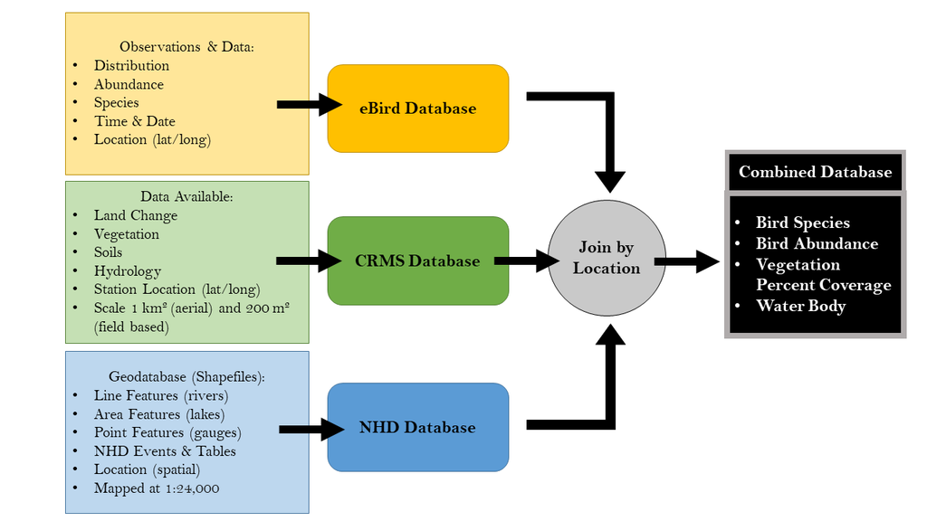

### Building the Database

We chose to use one year of data, 2021, as eBird data is more accurate in recent years, and CRMS and NHD are updated regularly. We specifically focused on the dates ranging from June 1- October 21, as this was the range for CRMS vegetation sampling (our most restricted dataset, temporally). We then selected and subset all eBird points within 1.25 miles of CRMS stations. This gave us a total of 4 CRMS stations and 75 eBird observations to include in our database. Similarly, we filtered the NHD waterbodies for all waterbodies within 1.25 miles of those same CRMS stations: CRMS0369, CRMS0414, CRMS0416, CRMS0434. This gave us a total of 117 waterbodies.

For each dataset, we needed to perform some data cleaning to facilitate integration into the database. This process is detailed below.

#### Ebird Data Preparation

```r
### Initialization -----------------------------

library(auk)

# Set AWK path (only necessary for Windows OS)
auk::auk_set_awk_path("C:/cygwin64/bin/gawk.exe/bin/gawk.exe",
                      overwrite=TRUE)

# Set eBird data directory
auk::auk_set_awk_path("C:/cygwin64/bin/gawk.exe/bin/gawk.exe",
                      overwrite=TRUE)

# Define path to the eBird data file
f_in <- "ebd_US-LA-109_relDec-2021.txt"

# Define output text file
f_out <- "ebd_filtered_LA.txt"


### Data Read-In -----------------------------

# Define reference file
ebd <- auk::auk_ebd(f_in)


### Data Cleaning -----------------------------

# Define filters - June 1, 2021 through October 21, 2021 in this case
ebd_filters <- auk::auk_date(ebd, date = c("2021-06-01", "2021-10-21"))

# Run the filtering
ebd_filtered <- auk::auk_filter(ebd_filters,
                                file = f_out,
                                overwrite = TRUE)

# Read filtered text file into R data frame
ebd_df <- auk::read_ebd(ebd_filtered)
```

#### CRMS Data Preparation

```r
### Initialization -----------------------------

library(tidyverse)
library(sf)

file.path <- "D:/Zack/School/Classes/Spring 22/OCS 7131 - Data Analysis in R/Lecture/Assignments/Assignment 2/"
# file.path <- "/Users/kloesser/Downloads/Assignment 2/"


### Data Read-In -----------------------------

veg.all <- read.csv(paste0(file.path, "CRMS_2021.csv")) # Veg percent cover at all avail. CRMS stations
coords <- read.csv(paste0(file.path, "CRMS_2021_Coordinates.csv")) # CRMS coords


### Data Cleaning -----------------------------
veg.coord <- merge(veg.all, coords, by = "Site_ID")

# isolate CRMS stations
CRMS0369 <- dplyr::filter(coords, Site_ID=="CRMS0369")
CRMS0414 <- dplyr::filter(coords, Site_ID=="CRMS0414")
CRMS0416 <- dplyr::filter(coords, Site_ID=="CRMS0416")
CRMS0434 <- dplyr::filter(coords, Site_ID=="CRMS0434")

sites <- c("CRMS0369", "CRMS0414", "CRMS0416", "CRMS0434")

# Filter veg to stations of interest
veg <- veg.coord[-which(is.na(match(veg.coord$Site_ID, sites))),]

# Get rid of empty columns
veg <- select(veg, Site_ID:Collection_Date, Longitude, Latitude)
```

#### NHD Data Preparation

```r
### Data Read-In -----------------------------

Terrebonne_wb <- read_sf("D:/Zack/School/Classes/Spring 22/OCS 7131 - Data Analysis in R/Lecture/Assignments/Assignment 2/NHDv2_Waterbodies_TerrebonneParish_WGS84.shp")
# Terrebonne_wb <- read_sf(paste0(file.path,"NHDv2_Waterbodies_TerrebonneParish_WGS84.shp"))
```

Following these initial steps, we filtered the datasets and combined them into one database as detailed below.

#### Filtering & combining datasets into one database

```r
library(lwgeom)

# Transform dataframes into sf objects
ebd_df_sf <- st_as_sf(ebd_df, coords=c("LONGITUDE","LATITUDE"))

CRMS0369_sf <- st_as_sf(CRMS0369, coords=c("Longitude", "Latitude"))
CRMS0414_sf <- st_as_sf(CRMS0414, coords=c("Longitude", "Latitude"))
CRMS0416_sf <- st_as_sf(CRMS0416, coords=c("Longitude", "Latitude"))
CRMS0434_sf <- st_as_sf(CRMS0434, coords=c("Longitude", "Latitude"))

veg_sf <- st_as_sf(veg, coords=c("Longitude", "Latitude"))


# Define common coordinate system
st_crs(ebd_df_sf) = 4326
st_crs(CRMS0369_sf) = 4326
st_crs(CRMS0414_sf) = 4326
st_crs(CRMS0416_sf) = 4326
st_crs(CRMS0434_sf) = 4326
st_crs(veg_sf) = 4326
st_crs(Terrebonne_wb) = 4326


# Filter for eBird observations within 2.012 kilometers (1.25 miles) of CRMS stations
distance <- units::set_units(2.012, km)

EbdCRMS0369 <- ebd_df_sf %>%
           dplyr::filter(st_is_within_distance(x = .,
                                               y = CRMS0369_sf,
                                               sparse = FALSE,
                                               dist = distance))

EbdCRMS0414 <- ebd_df_sf %>%
           dplyr::filter(st_is_within_distance(x = .,
                                               y = CRMS0414_sf,
                                               sparse = FALSE,
                                               dist = distance))

EbdCRMS0416 <- ebd_df_sf %>%
           dplyr::filter(st_is_within_distance(x = .,
                                               y = CRMS0416_sf,
                                               sparse = FALSE,
                                               dist = distance))

EbdCRMS0434 <- ebd_df_sf %>%
           dplyr::filter(st_is_within_distance(x = .,
                                               y = CRMS0434_sf,
                                               sparse = FALSE,
                                               dist = distance))


# Filter Terrebonne Water bodies within 2.012 km of a CRMS station
sf_use_s2(FALSE)

twbCRMS0369 <- Terrebonne_wb %>%
           dplyr::filter(st_is_within_distance(x = .,
                                               y = CRMS0369_sf,
                                               sparse = FALSE,
                                               dist = distance))

twbCRMS0414 <- Terrebonne_wb %>%
           dplyr::filter(st_is_within_distance(x = .,
                                               y = CRMS0414_sf,
                                               sparse = FALSE,
                                               dist = distance))

twbCRMS0416 <- Terrebonne_wb %>%
           dplyr::filter(st_is_within_distance(x = .,
                                               y = CRMS0416_sf,
                                               sparse = FALSE,
                                               dist = distance))

twbCRMS0434 <- Terrebonne_wb %>%
           dplyr::filter(st_is_within_distance(x = .,
                                               y = CRMS0434_sf,
                                               sparse = FALSE,
                                               dist = distance))


# Create a list for each CRMS station
CRMS0369_list <- vector(mode = "list", length = 3)
names(CRMS0369_list) <- c("vegetation", "birds", "waterbodies")
CRMS0414_list <- vector(mode = "list", length = 3)
names(CRMS0414_list) <- c("vegetation", "birds", "waterbodies")
CRMS0416_list <- vector(mode = "list", length = 3)
names(CRMS0416_list) <- c("vegetation", "birds", "waterbodies")
CRMS0434_list <- vector(mode = "list", length = 3)
names(CRMS0434_list) <- c("vegetation", "birds", "waterbodies")


# Attach data to lists
CRMS0369_list[[1]] <- filter(veg_sf, Site_ID == "CRMS0369")
CRMS0414_list[[1]] <- filter(veg_sf, Site_ID == "CRMS0414")
CRMS0416_list[[1]] <- filter(veg_sf, Site_ID == "CRMS0416")
CRMS0434_list[[1]] <- filter(veg_sf, Site_ID == "CRMS0434")

CRMS0369_list[[2]] <- EbdCRMS0369
CRMS0414_list[[2]] <- EbdCRMS0414
CRMS0416_list[[2]] <- EbdCRMS0416
CRMS0434_list[[2]] <- EbdCRMS0434

CRMS0369_list[[3]] <- twbCRMS0369
CRMS0414_list[[3]] <- twbCRMS0414
CRMS0416_list[[3]] <- twbCRMS0416
CRMS0434_list[[3]] <- twbCRMS0434


# Combine the four individual lists into one list (database)
db <- list(CRMS0369_list, CRMS0414_list, CRMS0416_list, CRMS0434_list)
names(db) <- sites
```

We were then able to explore novel data visualizations using our database.

### Visualizing Vegetation and Bird Species Richness

Initial visualization revealed that *Spartina patens* is one plant species with varying percent coverage across the four sites. Its coverage is highest at CRMS0416 (where it is also the species with the highest percent coverage: 34.5%), then decreases in abundance from CRMS0369 (where it is the second most abundant species, with a 19% coverage), to CRMS0434 (9%), and lastly to CRMS0414 (0%). We chose to explore how avian species richness varied with *S. patens* abundance within Terrebonne Parish, using these four CRMS stations.

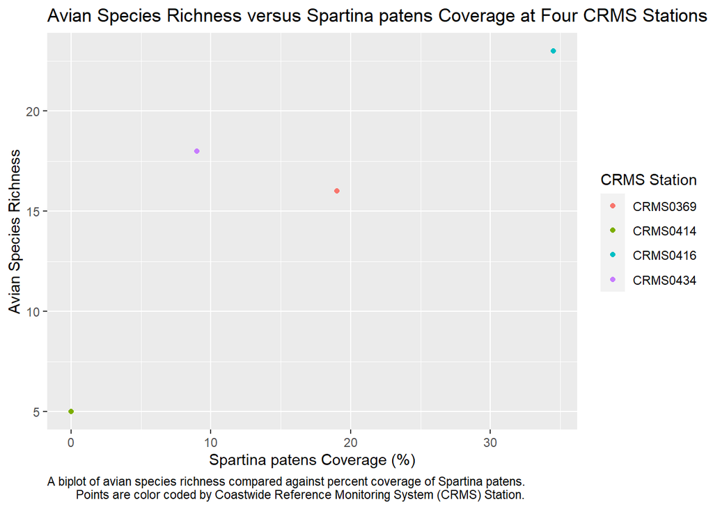

```r
### Data Cleaning -----------------------------

  # Isolate Spartina patens by CRMS station from the database
  veg_df <- as.data.frame(db$CRMS0369$vegetation)
  sppa0369 <- filter(veg_df, Symbol == "SPPA")

  # Attach number of bird species present at that station
  sppa0369$BirdRich <- length(unique(db$CRMS0369$birds$SCIENTIFIC_NAME))

  veg_df <- as.data.frame(db$CRMS0416$vegetation)
  sppa0416 <- filter(veg_df, Symbol == "SPPA")
  sppa0416$BirdRich <- length(unique(db$CRMS0416$birds$SCIENTIFIC_NAME))

  veg_df <- as.data.frame(db$CRMS0434$vegetation)
  sppa0434 <- filter(veg_df, Symbol == "SPPA")
  sppa0434$BirdRich <- length(unique(db$CRMS0434$birds$SCIENTIFIC_NAME))

  # Combine into one dataframe
  veg_bird <- rbind(sppa0369, sppa0416, sppa0434)

  # Add CRMS0414 (had no observations of Spartina patens)
  veg_bird[4, ] <- NA
  veg_bird[4,"Site_ID"] <- CRMS0414
  veg_bird[4,"percent_cover_derived"] <- 0
  veg_bird[4,"Symbol"] <- "SPPA"
  veg_bird[4,"BirdRich"] <- length(unique(db$CRMS0414$birds$SCIENTIFIC_NAME))

  ### Visualizing -----------------------------

  ggplot(veg_bird, aes(percent_cover_derived, BirdRich)) +
    geom_point(aes(color = Site_ID)) +
    labs(x = "Spartina patens Coverage (%)",
         y = "Avian Species Richness",
         caption = "A biplot of avian species richness compared against percent coverage of Spartina patens.
         Points are color coded by Coastwide Reference Monitoring System (CRMS) Station.",
         color = "CRMS Station",
          title = "Avian Species Richness versus Spartina patens Coverage at Four CRMS Stations") +
    theme(plot.caption = element_text(hjust = 0))
```

This figure demonstrates that for these sites in Terrebonne Parish, avian species richness is positively correlated with *Spartina patens* coverage.

### Mapping bird species richness at each CRMS station

Initial visualization revealed that avian species richness is positively correlated with percent cover of *Spartina patens*, a plant commonly found along coastal Louisiana. Because of this, we chose to explore how avian species richness varied spatially in Terrebonne parish.

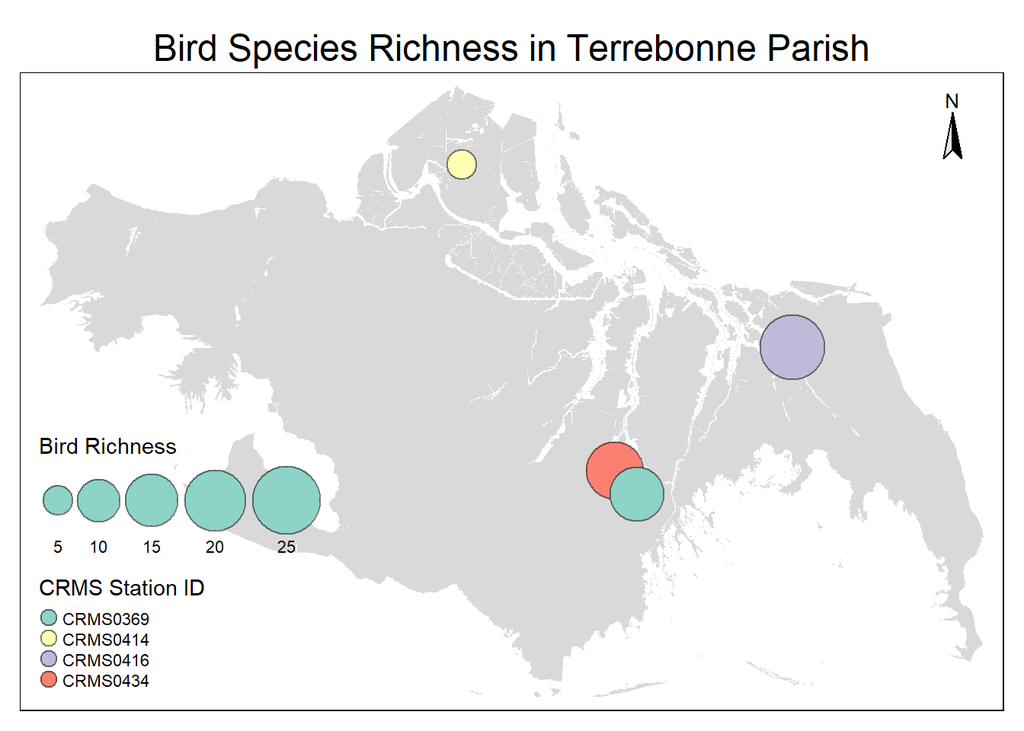

```r
library(tmap)

# Create spatial data frames containing bird species richness at each CRMS site
bird0369_sf <- st_sf(sppa0369)

bird0414 <- filter(veg_bird, Site_ID == "CRMS0414")
bird0414[1,"geometry"] <- db$CRMS0414$vegetation[c("geometry")]
bird0414_sf <- st_sf(bird0414)

bird0416_sf <- st_sf(sppa0416)

bird0434_sf <- st_sf(sppa0434)

# Set coordinate projection system for your spatial data frames
st_crs(bird0369_sf) = 4326
st_crs(bird0414_sf) = 4326
st_crs(bird0416_sf) = 4326
st_crs(bird0434_sf) = 4326

# Combine the individual spatial dataframes into one
bird_CRMS <- rbind(bird0369_sf, bird0414_sf, bird0416_sf, bird0434_sf)

# Add the data to a thematic map
tmap_mode("plot")

map_twb <- tm_shape(Terrebonne_wb) + tm_fill()

map_twb1 <- map_twb +
   tm_shape(bird_CRMS) + tm_bubbles(size = "BirdRich", col = "Site_ID", border.col = "black", border.alpha = 0.5,
                                    scale = 3, title.size = "Bird Richness", title.col = "CRMS Station ID") +
   tm_layout(main.title = "Bird Species Richness in Terrebonne Parish", main.title.position = "center",
            legend.position = c("left", "bottom", legend.is.portrait = FALSE)) + tm_compass(position = c("right", "top"),
                                                                                            color.light = "grey90")

map_twb1
```

### Visualizing overall bird abundance by waterbody type

Initial visualization revealed that the majority of waterbody types in Terrebonne parish were swamp/marsh habitat. Because of this, we chose to explore how overall bird abundance varied by waterbody type within Terrebonne Parish.

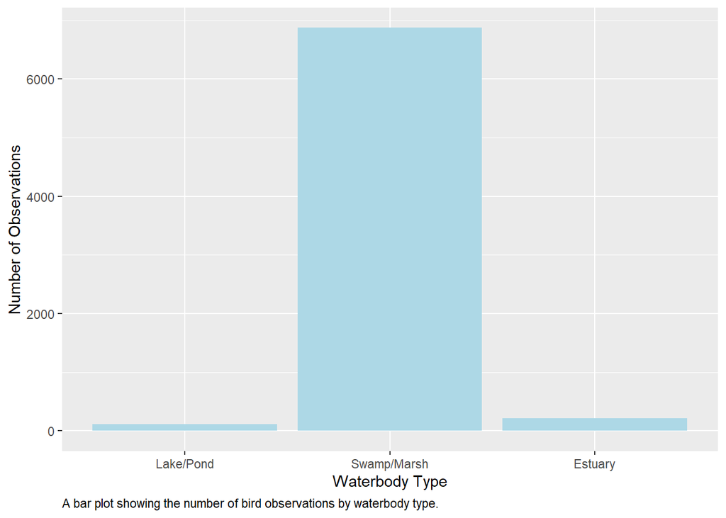

```r
### Data Cleaning -----------------------------

  # Create dataframes containing only CRMS Site IDs and bird observation counts
  water_df0369 <- as.data.frame(db$CRMS0369$waterbodies)
  water_df0369$Site_ID <- "CRMS0369"
  water_df0369$bird_obs <- sum(db$CRMS0369$birds$OBSERVATION_COUNT)

  water_df0414 <- as.data.frame(db$CRMS0414$waterbodies)
  water_df0414$Site_ID <- "CRMS0414"
  water_df0414$bird_obs <- sum(db$CRMS0414$birds$OBSERVATION_COUNT)

  water_df0416 <- as.data.frame(db$CRMS0416$waterbodies)
  water_df0416$Site_ID <- "CRMS0416"
  water_df0416$bird_obs <- sum(db$CRMS0416$birds$OBSERVATION_COUNT)

  water_df0434 <- as.data.frame(db$CRMS0434$waterbodies)
  water_df0434$Site_ID <- "CRMS0434"
  water_df0434$bird_obs <- sum(db$CRMS0434$birds$OBSERVATION_COUNT)

  # Combine the four dataframes
  water_birds <- rbind(water_df0369, water_df0414, water_df0416, water_df0434)

  water_birds$FCODE <- as.factor(water_birds$FCODE)

### Visualizing -----------------------------

library(ggplot2)
ggplot(water_birds, aes(x= FCODE, y= bird_obs)) + geom_bar(stat = "identity", fill="lightblue") + labs(x = "Waterbody Type", y= "Number of Observations", caption="A bar plot showing the number of bird observations by waterbody type.") + scale_x_discrete(labels= c("Lake/Pond", "Swamp/Marsh","Estuary")) + theme(plot.caption = element_text(hjust =0))
```

This plot demonstrates that for these sites in Terrebonne Parish, overall bird abundance between June 1st and October 21st was drastically greater in swamp/marsh habitat than in estuary and lake/pond habitat in 2021.

#### Roles:

*Beth Boos* wrote the text that was incorporated into the Rmarkdown, created the initial diagram explaining datasets used, and created the bar plot of bird diversity by waterbody type.

*Katie Loesser* compiled and filtered all the CRMS data for this assignment, did a lot of the formatting for the Rmarkdown document, helped a ton during the data preparation stage, and created the biplot of avian species richness.

*Zack Loken* downloaded and filtered both the eBird and NHD datasets for merging, made some final formatting edits, typed out most of the code while Katie told me what to type, and created the map of bird species richness per CRMS station in Terrebonne parish.